# asst 2 task 1

Casey O’Hara

1/28/2021

In your collaborative RMarkdown document, your group will explore adult fish passage recorded from 2001-01-01 to 2010-12-31 at the Willamette Falls fish ladder on the Willamette River (Oregon). Data were shared by and accessed from Columbia River DART (Data Access in Real Time).

You should include the following content:

# 1 Overview

This “Overview” section (above the tabs) should contain, in whatever order you choose:

- An engaging image (with caption, including photo credit) that is relevant to the dataset
- A brief summary (3 - 4 sentences) of the dataset, and what is included in this “report”
- A map of the fish ladder location (you can make this in R on your own, or include an existing map appropriately licensed, with attribution)
- A professionally formatted data citation

Remember: All code that you used to wrangle the data and prepare the graphs should be available to see if we click on the Code buttons.

## 1.1 Original time series

This “Time series” tab should contain: A finalized, static graph of adult passage for coho, jack coho, and steelhead salmon (you decide if these all occupy the same panel, or if they are in separate panels). Add a figure caption. Replace NA values with zero. 2 - 3 bulletpoints summarizing major patterns / notable trends in the salmon passage time series data Remember: All code that you used to wrangle the data and prepare the graphs should be available to see if we click on the Code buttons.

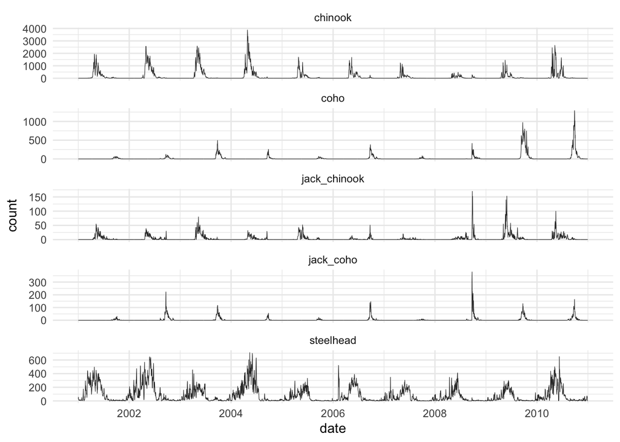

```r
salmon_ts <- read_csv(here('willamette_fish_passage.csv')) %>%
  janitor::clean_names() %>%
  select(date, coho, jack_coho, steelhead, chinook, jack_chinook, temp_c) %>%
  gather(salmon, count, coho:jack_chinook) %>%
  mutate(date = lubridate::mdy(date),
         count = ifelse(is.na(count) | count < 0, 0, count)) %>%
  as_tsibble(index = date, key = salmon)

ggplot(salmon_ts, aes(x = date, y = count)) +
  theme_minimal() +
  geom_line(color = 'grey20', size = .2) +
  facet_wrap(~ salmon, ncol = 1, scales = 'free_y')
```

## 1.2 Seasonplots

This “Seasonplots” tab should contain:

- A finalized seasonplot for each species (coho, jack coho, steelhead). You can either facet, or use patchwork, to make the figure. Add a caption.
- Add 2 - 3 bulletpoints summarizing the major trends you see in the seasonplots.

Remember: All code that you used to wrangle the data and prepare the graphs should be available to see if we click on the Code buttons.

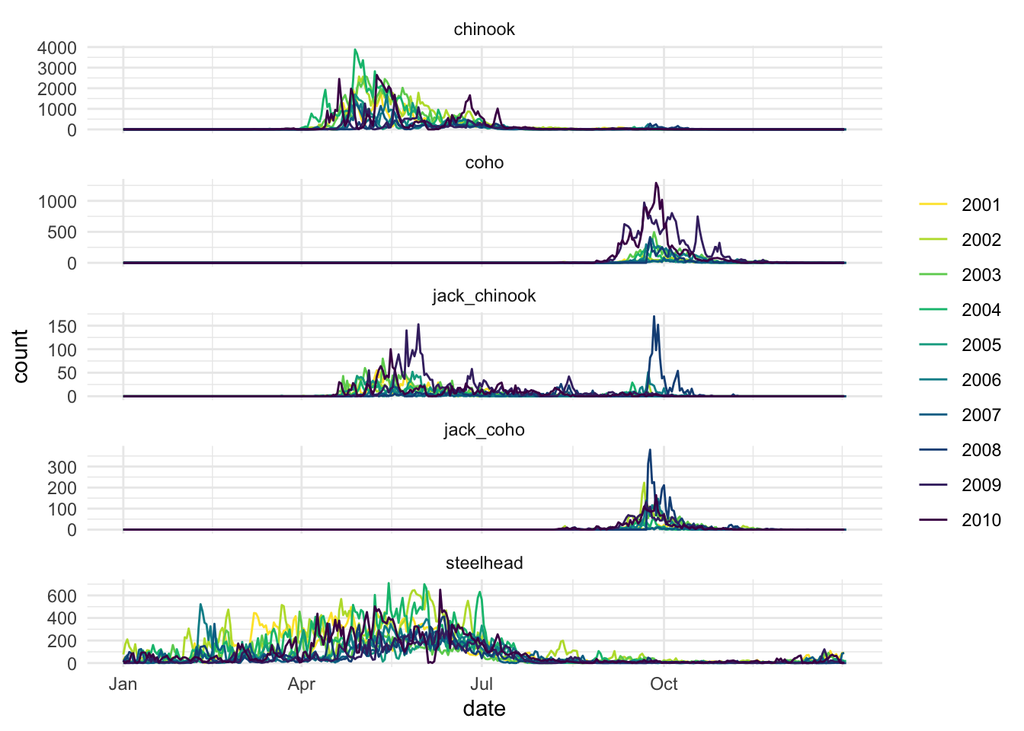

```r
salmon_ts <- read_csv(here('willamette_fish_passage.csv')) %>%
  janitor::clean_names() %>%
  select(date, coho, jack_coho, steelhead, chinook, jack_chinook, temp_c) %>%
  gather(salmon, count, coho:jack_chinook) %>%
  mutate(date = lubridate::mdy(date),
         count = ifelse(is.na(count) | count < 0, 0, count)) %>%
  as_tsibble(index = date, key = salmon)

gg_season(salmon_ts, y = count, pal = hcl.colors(10, rev = TRUE)) +
  theme_minimal() +
  facet_wrap(~ salmon, ncol = 1, scales = 'free_y')
```

## 1.3 Annual counts by species

This “Summary statistics and analysis” tab should contain:

- A finalized figure of annual totals for fish passage, for each of the 3 species (coho, jack coho, steelhead). You decide if this is in a single panel, or multiple panels. Add a figure caption.
- Add 2 - 3 bulletpoints summarizing major trends you see in the annual totals by species from 2000 - 2010.

Remember: All code that you used to wrangle the data and prepare the graphs should be available to see if we click on the Code buttons.

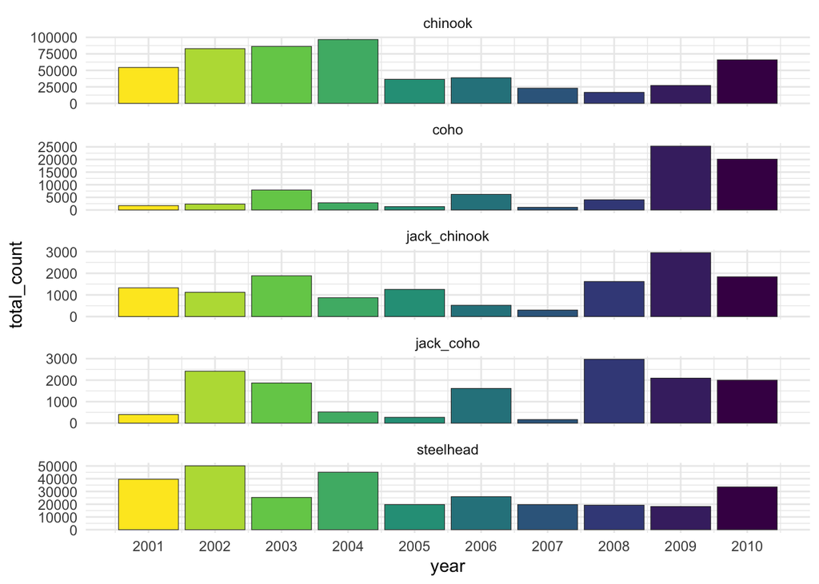

```r
salmon_ts <- read_csv(here('willamette_fish_passage.csv')) %>%
  janitor::clean_names() %>%
  select(date, coho, jack_coho, steelhead, chinook, jack_chinook, temp_c) %>%
  gather(salmon, count, coho:jack_chinook) %>%
  mutate(date = lubridate::mdy(date),
         count = ifelse(is.na(count) | count < 0, 0, count)) %>%
  as_tsibble(index = date, key = salmon)

salmon_totals <- salmon_ts %>%
  group_by_key() %>%
  index_by(year = ~lubridate::year(.)) %>%
  summarize(total_count = sum(count))

ggplot(salmon_totals, aes(x = year, y = total_count, fill = year)) +
  theme_minimal() +
  geom_col(color = 'grey20', size = .2, show.legend = FALSE) +
  scale_fill_viridis_c(direction = -1) +
  scale_x_continuous(breaks = 2001:2010) +
  facet_wrap(~ salmon, ncol = 1, scales = 'free_y')
```